# latinR proposal: Flipping the sf plotting script with new geography-specific Stats

Evangeline Reynolds

2024-08-26

# Status quo mapping with ggplot2’s geom_sf()

ggplot2 is a beloved graphical system because of it’s elegance and flexibility. Usually a graph requires the user to specify three elements (and ggplot2 can take care of the rest):

1. **data** - which dataframe will be the basis of the graphic
2. **aesthetic mapping** - should variables be represented by x position, y position, color, linewidth etc, and
3. **geom**, the mark that should take on these aesthetics.

ggplot2 added more geographic viz capabilities with the addition of it’s geom_sf_*() functions. However, geographic mapping with geom_sf may feel a little out-of-step with ggplot2’s other plot builds, as the user doesn’t have to map any aesthetics to build a map! (?!) Let’s consider creating a choropleth of characteristic that varies with geographic area. Here’s example syntax.

```r
library(tidyverse)
# get shape data
nc_shapes <- sf::st_read(system.file("shape/nc.shp", package = "sf"), quiet = TRUE)

# get
my_nc_data_w_shapes <- nc_shapes %>% left_join(my_nc_data, by = "county_name")

ggplot(nc) +
  geom_sf()

last_plot() +
  aes(fill = my_var)
```

A first step is to find shape data for the areas of interest, ideally in a data frame with one column identifying the geographic area, and another list-column often named `geometry` with the geographic information included. Then the actual data of interest is joined to the geography data frame via the identifying column. Then this data can be input into ggplot(). To render a map, geom_sf() can be added with no aesthetic mapping required, because under the hood, this layer is directed to look for a column named `geometry`. But to make the map a choropleth, aesthetic mapping instruction `aes(fill = my_var)` would be required.

Whereas so many geoms *require* at least one positional aesthetic (x and y) to be declared in plot syntax, sf weirdly doesn’t - as it’s all managed with precomputation and under-the-hood column discovery.

# A new way: geography-specific layers (when aesthetic mapping is really about *mapping*)

This talk will propose creating a Stat to allow for a workflow that’s more similar to the ‘classic’ ggplot2 build, and ready for repeat use. The new layer that’s propose would *require* a positional aesthetic to be declared by the user - but this will feel a little different from x and y, instead being a geographic aesthetic - ids of a geographic location (names, codes, abbreviations, etc). The proposed syntax example:

```r
ggplot(my_nc_data) +
  aes(county_name = county) +
  geom_sf_county()

last_plot() +
  aes(fill = my_var)
```

A micro, but usable preparation is as follows:

```r
## some flat data we might want to make a choropleth with
region_poblacion %>%
  head()
```

```
## # A tibble: 6 × 2
##   region poblacion
##   <chr>      <dbl>
## 1 01        318724
## 2 02        579305
## 3 03        264856
## 4 04        707918
## 5 05       1721779
## 6 06        865190
```

```r
## some geographic shape data
chile_regiones <- chilemapas::generar_regiones()

## Prep reference data for Stat (NEW!)
geo_reference_chile_region <- chile_regiones |>
  dplyr::select(region_codigo = codigo_region) |>
  ggplot2::StatSf$compute_panel(coord = ggplot2::CoordSf) |>
  ggplot2::StatSfCoordinates$compute_group(coord = ggplot2::CoordSf)

# Flip the script... prepare compute (join) to happen in layer (NEW!)
compute_panel_region <- function(data, ...){

  data %>% inner_join(geo_reference_chile_region)

}

# Write a dedicated stat to do the join for you (NEW!)
StatRegion <- ggproto(`_class` = "StatRegion",
                      `_inherit` = ggplot2::Stat,
                      compute_panel = compute_panel_region,
                      required_aes = "region_codigo"
                      )

head(region_poblacion)
```

```
## # A tibble: 6 × 2
##   region poblacion
##   <chr>      <dbl>
## 1 01        318724
## 2 02        579305
## 3 03        264856
## 4 04        707918
## 5 05       1721779
## 6 06        865190
```

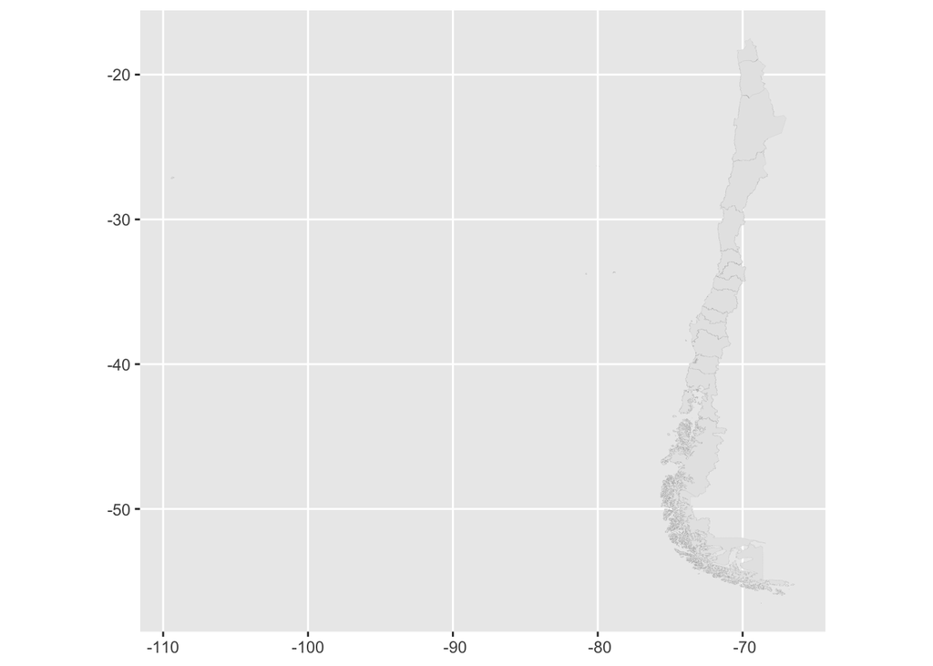

```r
region_poblacion |>
  ggplot() +
  aes(region_codigo = region) +
  geom_sf(stat = StatRegion, linewidth = .01)
```

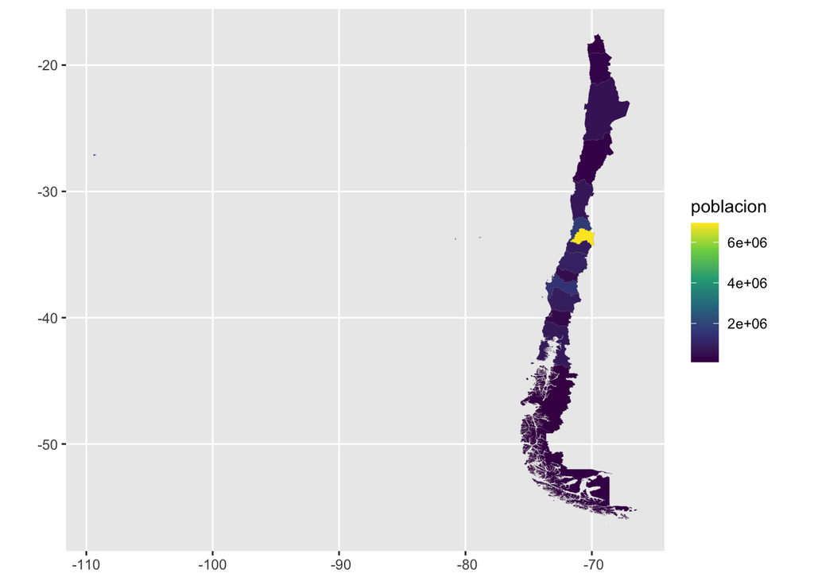

```r
last_plot() +
  aes(fill = poblacion) +
  scale_fill_viridis_c()
```

A basic user-facing function can be written like this.

```r
geom_region <- function(...){ geom_sf(stat = StatRegion, ...)} # (express-type layer - currently undergoing vetting)
```

The question this exercise raises is, could packages like chilemapas, geobrasil, geoAr, mapasPERU, geouy, as well packages with data about other parts of the world, not only provide the awesome interfaces to the geogarphic data they do, but possibly also plotting functionality like the above geom_region? Then with the Stat and geom_region() from this package, you’d be able to build choropleths in a snap, without the precomputation, etc. So then getting from your flat dataframe that has region numbers and population as columns to choropleth would look like this:

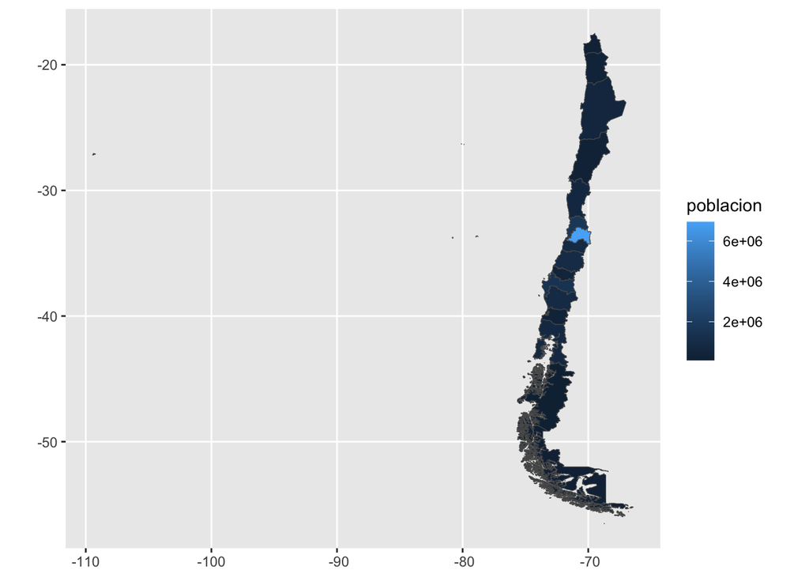

```r
library(chilemapas)

region_poblacion %>%
  ggplot() +
  aes(region_codigo = region) +
  geom_region() + # proposed chilemapas (?) plotting function
  aes(fill = poblacion)
```

Another, lower maintanence approach would be to provide documentation on how to build geography-specific Stats, so that organizations like Chilean universities, news organizations, etc, could use the ‘flipped script’ approach which might make map building more intuitive and fun.